[figure not shown]

# Makro II: Zusätzliches Material

by Markus Mößler

# Wohlstand Beschreiben und Erklären

*Dieses Dokument enthält ausgewählter Zeitreihen zur Analyse von Wohlstand.*

## Einführung

### Einordnung

Einordnung

Für die Einordnung siehe auch Kapitel 2.2 “Vermessung von Wohlstand”.

- Mengen:
  - Einkommen $\left(Y\right)$
  - Konsum $\left(C\right)$
  - Investitionen $\left(I\right)$
  - Liquidität $\left(L\right)$
  - Nettoexporte $\left(NX\right)$ und Nettokapitalexporte $\left(NKE\right)$
  - Staatsausgaben $\left(G\right)$
  - Staatseinnahmen $\left(T\right)$
- Preise:
  - Inflationsrate $\left(P, \pi\right)$
  - Zinsen $\left(i, r\right)$
  - Wechselkurse $\left(e, \varepsilon\right)$

### Vorbereitung

Vorbereitung

Vorbereitung des *R*-Skripts:

1. Setzen des Arbeitspfades

```r
# setwd("... insert-you-directory-here ...")
```

2. Laden der nötigen Pakete zu Datenverarbeitung

```r
library(dplyr)
library(tidyr)
library(ggplot2)
library(kableExtra)
library(scales)
library(zoo)
library(ecm)
```

3. Laden der Grafikvorlage

```r
mod.theme.01 <- theme_gray() + theme(axis.text.x = element_text(angle = 90, vjust = 0.5, size = 12),
                                     axis.text.y = element_text(size = 12),
                                     plot.title = element_text(size = 16),
                                     plot.subtitle = element_text(size = 12),
                                     plot.caption = element_text(size = 12),
                                     legend.text = element_text(size = 12))

mod.theme.01$legend.position <- c("bottom")
```

Die Daten werden von unterschiedlichen öffentlich zugänglichen Datenbanken heruntergeladen.

Die Daten können entweder auf der Website oder über so genannte Programmierschnittstellen (APIs) heruntergeladen werden.

### FRED

FRED

Die Daten von der Federal Reserve Bank of St. Louis können mit dem *R*-Paket `fredr` heruntergeladen werden.

- Link: [FRED: Startseite](https://fred.stlouisfed.org/)

Um Daten über die FRED-API müssen Sie sich zuerst kostenlos registrieren und einen “API Key” beantragen ([siehe](https://fred.stlouisfed.org/docs/api/api_key.html)).

Diesen “API Key” müssen Sie anschließend mit der *R*-Funktion `fredr_set_key` angeben.

```r
# FRED
library(fredr)
# Set your fredr key here
fredr_set_key("... insert-your-personal-key-here ...")
```

Zur Schattierung der Rezessionen (siehe: [NBER](https://www.nber.org/research/business-cycle-dating)) verwenden wir die folgende *R*-Funktion.

```r
# See: https://rpubs.com/FSl/609471 (and edite by MM)
add_rec_shade <- function(st_date, ed_date, shade_color = "darkgray", zoo.mon = FALSE, zoo.qtr = FALSE) {

  recession  <-  fredr(series_id = "USRECD",observation_start = as.Date(st_date),observation_end = as.Date(ed_date))

  recession$diff <- recession$value-lagpad(recession$value, k = 1)
  recession <- recession[!is.na(recession$diff),]
  recession.start <- recession[recession$diff == 1,]$date
  recession.end <- recession[recession$diff == (-1),]$date

  if(length(recession.start) > length(recession.end)) {
    recession.end <- c(recession.end, Sys.Date())
  }
  if(length(recession.end)>length(recession.start)) {
    recession.start <- c(min(recession$date), recession.start)
  }

  recs <- as.data.frame(cbind(recession.start, recession.end))
  recs$recession.start <- as.Date(as.numeric(recs$recession.start), origin = as.Date("1970-01-01"))

  if(zoo.mon == TRUE){
    recs$recession.start <- as.yearmon(recs$recession.start, "%b%y")
  }
  if(zoo.qtr == TRUE){
    recs$recession.start <- as.yearqtr(recs$recession.start, "%y-Q%q")
  }

  recs$recession.end <- as.Date(recs$recession.end, origin = as.Date("1970-01-01"))

  if(zoo.mon == TRUE){
    recs$recession.end <- as.yearmon(recs$recession.end, "%b%y")
  }
  if(zoo.qtr == TRUE){
    recs$recession.end <- as.yearqtr(recs$recession.end, "%y-Q%q")
  }

  if(nrow(recs) > 0) {
    rec_shade <- geom_rect(data = recs, inherit.aes = FALSE,
                           aes(xmin = recession.start, xmax = recession.end, ymin = -Inf, ymax = +Inf),
                           fill = shade_color, alpha = 0.5)

    return(rec_shade)
  }

}
```

### Eurostat and ECB

Eurostat and ECB

Die Daten von Eurostat und der EcB können mit dem *R*-Paket `eurostat` und `ecb` heruntergeladen werden.

Links:

- [Eurostat: Startseite](https://ec.europa.eu/eurostat/de/home)
- [ECB: Statistical Data Warehouse](https://sdw.ecb.europa.eu)

```r
# eurostat
library(eurostat)
# ecb statistical data warehouse
library(ecb)
```

## Mengen

### USA

Reales BIP (Niveau)

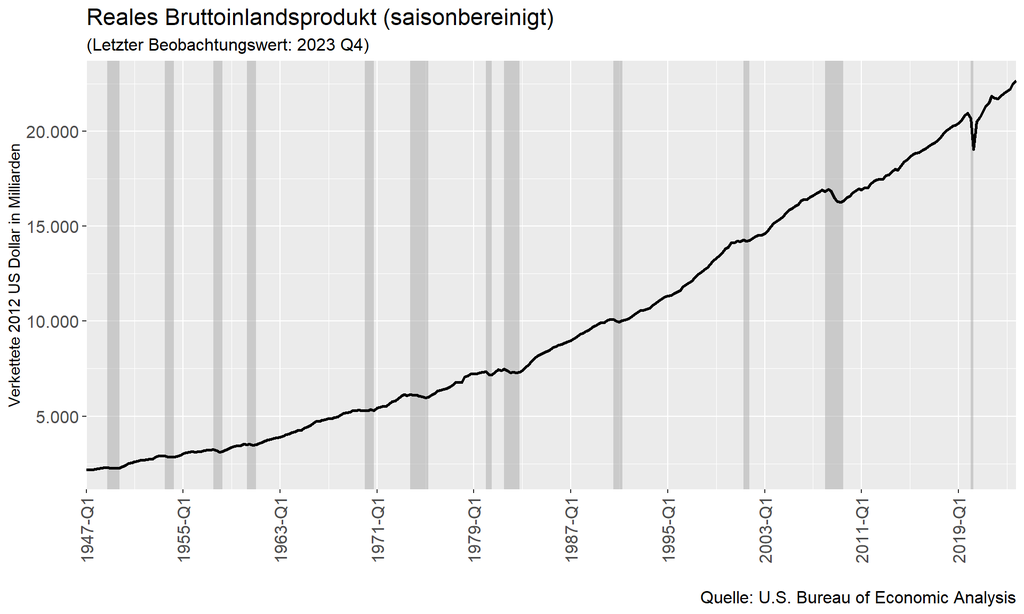

| Date | Period | Value |
| --- | --- | --- |
| 2021-07-01 | 2021 Q3 | 21.483,08 |
| 2021-10-01 | 2021 Q4 | 21.847,60 |
| 2022-01-01 | 2022 Q1 | 21.738,87 |
| 2022-04-01 | 2022 Q2 | 21.708,16 |
| 2022-07-01 | 2022 Q3 | 21.851,13 |
| 2022-10-01 | 2022 Q4 | 21.989,98 |
| 2023-01-01 | 2023 Q1 | 22.112,33 |
| 2023-04-01 | 2023 Q2 | 22.225,35 |
| 2023-07-01 | 2023 Q3 | 22.490,69 |
| 2023-10-01 | 2023 Q4 | 22.672,86 |

```r
# Meta data
met.dat <- fredr_series_search_text("GDPC1")

# Data
ser.dat <- fredr_series_observations(series_id = met.dat$id[1],
                                     observation_start = as.Date("1947-01-01"),
                                     units = "lin")

# Transform date to yearmon class
ser.dat$date.zoo <- as.yearqtr(ser.dat$date, "%y-Q%q")

# Construct plot
plot <- ggplot(data = ser.dat, mapping = aes(x=date.zoo, y = value, color = series_id)) +
  add_rec_shade(min(ser.dat$date), max(ser.dat$date), zoo.mon = FALSE, zoo.qtr = TRUE) +
  geom_line(color = "black", size = 1) +
  scale_x_yearqtr(breaks = seq(from = min(ser.dat$date.zoo), to = max(ser.dat$date.zoo), by = 8),
                  minor_breaks = seq(from = min(ser.dat$date.zoo), to = max(ser.dat$date.zoo), by = 4),
                  format = "%Y-Q%q",
                  expand = c(0, 0)) +
  scale_y_continuous(labels = comma_format(big.mark = ".", decimal.mark = ",")) +
  labs(title = "Reales Bruttoinlandsprodukt (saisonbereinigt)",
       subtitle = paste0(c("(Letzter Beobachtungswert: "), as.yearqtr(as.Date(met.dat$observation_end)), c(")")),
       caption = "Quelle: U.S. Bureau of Economic Analysis",
       x = "", y = "Verkettete 2012 US Dollar in Milliarden") +
  mod.theme.01

# Return plot
plot
```

Reales BIP (Veränderung)

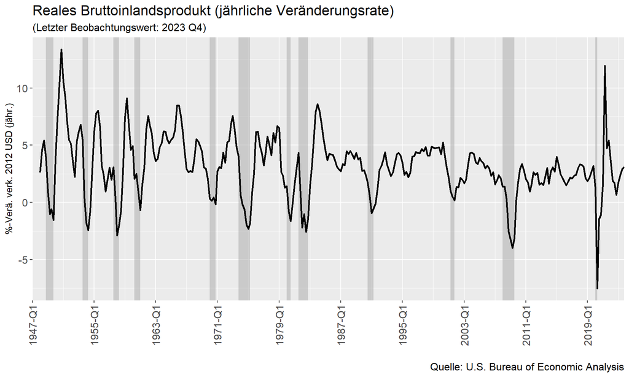

| Date | Period | Value |
| --- | --- | --- |
| 2021-07-01 | 2021 Q3 | 4,73532 |
| 2021-10-01 | 2021 Q4 | 5,42109 |
| 2022-01-01 | 2022 Q1 | 3,56508 |
| 2022-04-01 | 2022 Q2 | 1,87060 |
| 2022-07-01 | 2022 Q3 | 1,71321 |
| 2022-10-01 | 2022 Q4 | 0,65169 |
| 2023-01-01 | 2023 Q1 | 1,71793 |
| 2023-04-01 | 2023 Q2 | 2,38247 |
| 2023-07-01 | 2023 Q3 | 2,92689 |
| 2023-10-01 | 2023 Q4 | 3,10541 |

```r
# Meta data
met.dat <- fredr_series_search_text("GDPC1")

# Data
ser.dat <- fredr_series_observations(series_id = met.dat$id[1],
                                     observation_start = as.Date("1947-01-01"),
                                     units = "pc1")

# Transform date to yearmon class
ser.dat$date.zoo <- as.yearqtr(ser.dat$date, "%y-Q%q")

# Construct plot
plot <- ggplot(data = ser.dat, mapping = aes(x=date.zoo, y = value, color = series_id)) +
  add_rec_shade(min(ser.dat$date), max(ser.dat$date), zoo.mon = FALSE, zoo.qtr = TRUE) +
  geom_line(color = "black", size = 1) +
  scale_y_continuous(labels = comma_format(big.mark = ".", decimal.mark = ",")) +
  scale_x_yearqtr(breaks = seq(from = min(ser.dat$date.zoo), to = max(ser.dat$date.zoo), by = 8),
                  minor_breaks = seq(from = min(ser.dat$date.zoo), to = max(ser.dat$date.zoo), by = 4),
                  format = "%Y-Q%q",
                  expand = c(0, 0)) +
  labs(title = "Reales Bruttoinlandsprodukt (jährliche Veränderungsrate)",
       subtitle = paste0(c("(Letzter Beobachtungswert: "), as.yearqtr(as.Date(met.dat$observation_end)), c(")")),
       caption = "Quelle: U.S. Bureau of Economic Analysis",
       x = "", y = "%-Verä. verk. 2012 USD (jähr.)") +
  mod.theme.01

# Return plot
plot
```